# R_Assignment3

1.To find out a effect between N to E, we model E as a function of N and M

```r
install.packages('kableExtra')
```

```
## Error in install.packages : Updating loaded packages
```

```r
library(broom)
model.E = lm(milk.energy ~ neocortex.frac+log10mass , data = mk_df)
summary(model.E) |>
  tidy() |>
  knitr::kable(digits = c(NA,1,1,1,4)) |>
  kableExtra::kable_classic(full_width = FALSE)
```

| term | estimate | std.error | statistic | p.value |
| --- | --- | --- | --- | --- |
| (Intercept) | -1.1 | 0.5 | -2.1 | 0.0551 |
| neocortex.frac | 2.8 | 0.8 | 3.5 | 0.0038 |
| log10mass | -0.2 | 0.1 | -3.9 | 0.0017 |

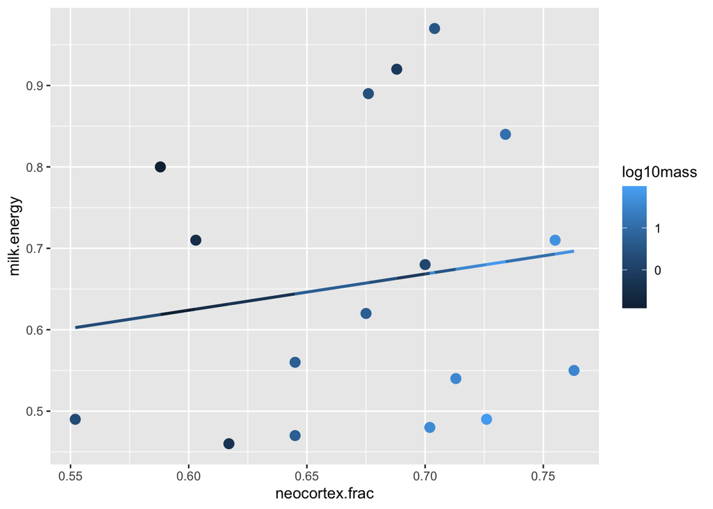

```r
# Fit the model
model_E <- lm(milk.energy ~ neocortex.frac, data = mk_df)

# Make predictions
mk_df$pred_model_add <- predict(model_E, newdata = mk_df)

# Plot the data and predictions
library(ggplot2)
p <- ggplot(mk_df, aes(x = neocortex.frac, y = milk.energy, colour = log10mass)) +
  geom_point(size = 3) +
  geom_line(aes(y = pred_model_add), lwd = 1)

print(p)
```

The table above shows, both M and N related to E.From the plot, we can conclude, the smaller average body mass of adult females(M), the higher energy density of milk (E), which It is verified that hypothesis one is correct.

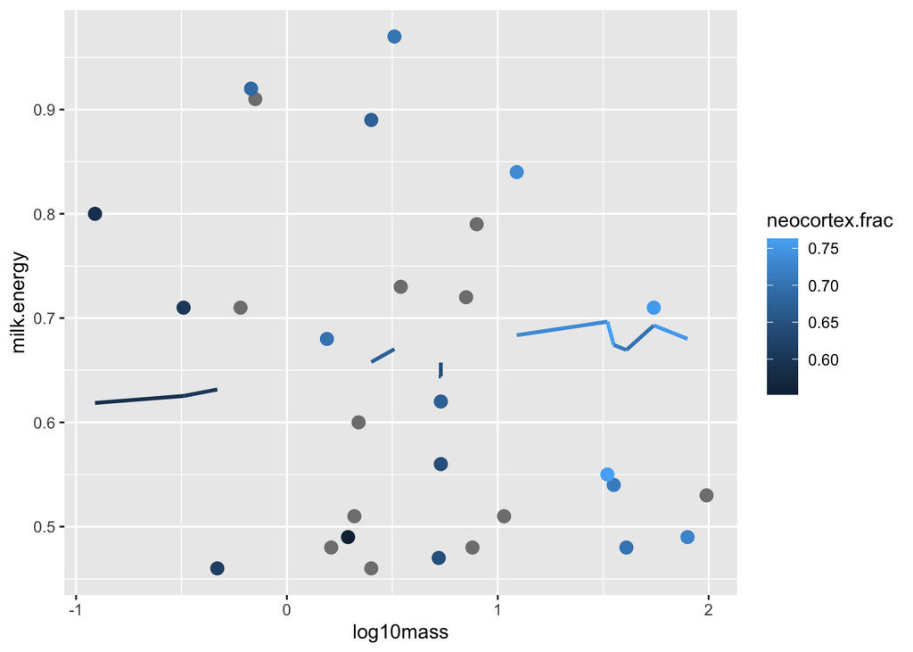

```r
library(ggplot2)
p <- ggplot(mk_df, aes(x = log10mass, y = milk.energy, colour = neocortex.frac)) +
  geom_point(size = 3) +
  geom_line(aes(y = pred_model_add), lwd = 1)

print(p)
```

```r
# find the relationship between N and M
# fit a linear regression model with N as the predictor and M as the response

model_NM = lm (log10mass~ neocortex.frac, data=mk_df)
summary(model_NM)
```

```
##
## Call:
## lm(formula = log10mass ~ neocortex.frac, data = mk_df)
##
## Residuals:
##      Min       1Q   Median       3Q      Max
## -0.95196 -0.37611 -0.05241  0.40123  0.94139
##
## Coefficients:
##                Estimate Std. Error t value Pr(>|t|)
## (Intercept)      -6.469      1.622  -3.987 0.001189 **
## neocortex.frac   10.539      2.392   4.405 0.000511 ***
## ---
## Signif. codes:  0 '***' 0.001 '**' 0.01 '*' 0.05 '.' 0.1 ' ' 1
##
## Residual standard error: 0.5715 on 15 degrees of freedom
##   (12 observations deleted due to missingness)
## Multiple R-squared:  0.564,  Adjusted R-squared:  0.535
## F-statistic: 19.41 on 1 and 15 DF,  p-value: 0.0005114
```

the p value is 0.0005114, which show a significant relation between N and M. From the plot above, we can observe that at the same position on the x-axis, the dots exhibit a lighter blue color when E is higher. This indicates a positive relationship between N and E, providing support for the second hypothesis.

To identify whether U is independent of N given M,firstly,we should fit a linear model between U and N,if they are independent, and when conditioned on M, U and N become dependent, then M is the collider of N and U, then scheme A2 is verified.

Question 5 Predict what the milk energy density in humans would become if a selection pressure would cause the neocortex fraction to increase from currently 0.755 to 0.770 in the future. Describe your plan and reasoning behind it to answer this question. Which other variables would likely also change?

Answer: Prefiction: if a selection pressure would cause the neocortex fraction to increase from currently 0.755 to 0.770 in the future, the milk enerfy density in human would become higher.

My plan: 1、Fit a linear model between N and E. 2. Obtain the coefficient estimates from linear model, using the coeficient estimates, predict change in E when given the change in N. 3. Calculate the predict value of E using the new value of N (0.770). 4. Compare the value in different value of N.

Reasoning: 1. The linear model provides an estimate of the relationship between two variables based on the observed data. 2. by using the coefficients estimates from the model, we can predict the change in E associated with a given change in N.

The possible changed variables are: brain size, higher metabolic rate and longer lifespan or lower body mass.

References: Burini, R.C., and Leonard, W.R. (2018) The evolutionary roles of nutrition selection and dietary quality in the human brain size and encephalization. Nutrire 43. Herculano-Houzel, S. (2012) The remarkable, yet not extraordinary, human brain as a scaled-up primate brain and its associated cost. Proceedings of the National Academy of Sciences 109: 10661–10668. Hinde, K., and Milligan, L.A. (2011) Primate milk: Proximate mechanisms and ultimate perspectives. Evolutionary Anthropology 20: 9–23. Kleiber, M. (1947) Body size and metabolic rate. Physiological Reviews 27: 511–541. West, G.B., Brown, J.H., and Enquist, B.J. (1999) The fourth dimension of life: Fractal geometry and allometric scaling of organisms. Science 284: 1677–1679.